# DiseaseOutbreaks

Wasted Potential: Sneha Kuchipudi, RyeAnne Ricker, Yuqi Chen, Benjamin Lee

4/2/2020

```r
xkabledply = function(modelsmmrytable, title="Table", digits = 4, pos="left", bso="striped") {
  #' Combining base::summary, xtable, and kableExtra, to easily display model summary.
  #' wrapper for the base::summary function on model objects
  #' ELo 202004 GWU DATS
  #' version 1.2
  #' @param modelsmmrytable This can be a generic table, a model object such as lm(), or the summary of a model object summary(lm())
  #' @param title Title of table.
  #' @param digits Number of digits to display
  #' @param pos Position of table, c("left","center","right")
  #' @param bso bootstrap_options = c("basic", "striped", "bordered", "hover", "condensed", "responsive")
  #' @return HTML table for display
  #' @examples
  #' library("xtable")
  #' library("kableExtra")
  #' xkabledply( df, title="Table testing", pos="left", bso="hover" )
  modelsmmrytable %>%
    xtable() %>%
    kable(caption = title, digits = digits) %>%
    kable_styling(bootstrap_options = bso, full_width = FALSE, position = pos)
}

xkablesummary = function(df, title="Table: Statistics summary.", digits = 4, pos="left", bso="striped") {
  #' Combining base::summary, xtable, and kableExtra, to easily display numeric variable summary of dataframes.
  #' ELo 202004 GWU DATS
  #' version 1.2
  #' @param df The dataframe.
  #' @param title Title of table.
  #' @param digits Number of digits to display
  #' @param pos Position of table, c("left","center","right")
  #' @param bso bootstrap_options = c("basic", "striped", "bordered", "hover", "condensed", "responsive")
  #' @return The HTML summary table for display, or for knitr to process into other formats
  #' @examples
  #' xkablesummary( faraway::ozone )
  #' xkablesummary( ISLR::Hitters, title="Five number summary", pos="left", bso="hover"  )

  s = summary(df) %>%
    apply( 2, function(x) stringr::str_remove_all(x,c("Min.\\s*:\\s*","1st Qu.\\s*:\\s*","Median\\s*:\\s*","Mean\\s*:\\s*","3rd Qu.\\s*:\\s*","Max.\\s*:\\s*")) ) %>% # replace all leading words
    apply( 2, function(x) stringr::str_trim(x, "right")) # trim trailing spaces left

  colnames(s) <- stringr::str_trim(colnames(s))

  if ( dim(s)[1] ==6 ) { rownames(s) <- c('Min','Q1','Median','Mean','Q3','Max')
  } else if ( dim(s)[1] ==7 ) { rownames(s) <- c('Min','Q1','Median','Mean','Q3','Max','NA') }

  xkabledply(s, title=title, digits = digits, pos=pos, bso=bso )
}

xkablevif = function(model, title="VIFs of the model", digits = 3, pos="left", bso="striped") {
  #' Combining faraway::vif, xtable, and kableExtra, to easily display numeric summary of VIFs for a model.
  #' ELo 202004 GWU DATS
  #' version 1.2
  #' @param model The lm or compatible model object.
  #' @param title Title of table.
  #' @param digits Number of digits to display
  #' @param pos Position of table, c("left","center","right")
  #' @param bso bootstrap_options = c("basic", "striped", "bordered", "hover", "condensed", "responsive")
  #' @return The HTML summary table of the VIFs for a model for display, or for knitr to process into other formats
  #' @examples
  #' xkablevif( lm(Salary~Hits+RBI, data=ISLR::Hitters) )

  vifs = table( names(model$coefficients)[2:length(model$coefficients)] ) # remove intercept to set column names
  vifs[] = faraway::vif(model) # set the values
  xkabledply( vifs, title=title, digits = digits, pos=pos, bso=bso )
}
```

## Pre-processing and Summary of the Dataset

Upon reading in our dataset, the variable types were conveniently all correct. Our categorical variables are all factors and our numerical features (illnesses, hospitalizations and fatalities) and year variable are all of type “int.” The number of observations in our dataset is 19,119 and the number of variables is 12.

Here, the data is read in as ‘outbreaks.’ Notice that there are two read-ins; one is for use in pre-processing and model building, while the other is used for EDA.

```r
outbreaks <- read.csv('outbreaks.csv')

str(outbreaks)

summary(outbreaks)

outbreak <- read.csv("outbreaks.csv")
summary(outbreak)
str(outbreak)
```

#### Missing Data

After skimming through the data set, We noticed that several predictors contained a large number of missing values. It is important to note that the missing values are denoted as ’’ instead of ‘NA.’ The largest occurances of missing values were in Serotype/Genotype (15,212 points, or 79.56% of datatset) and Ingredient (17,243 points, or 90.18% of dataset). Food contained 8,963 missing values (46.88% of dataset). Species and Status also contained a respectable number of missing values (6,619 points, or 34.62% of dataset).

```r
year_na <- subset(outbreaks, Year == '') # 0 missing values

month_na <- subset(outbreaks, Month == '') # 0 missing values

location_na <- subset(outbreaks, Location == '') # 2,166 missing values (11.32% of dataset)

food_na <- subset(outbreaks, Food == '') # 8,963 missing values (46.88% of dataset)

ingredient_na <- subset(outbreaks, Ingredient == '') # 17,243 missing values (90.18% of dataset)

species_na <- subset(outbreaks, Species == '') # 6,619 missing values (34.62% of dataset)

serotype.genotype_na <- subset(outbreaks, Serotype.Genotype == '') # 15,212 missing values (79.56% of dataset)

status_na <- subset(outbreaks, Status == '') # 6,619 missing values (34.62% of dataset)

illnesses_na <- subset(outbreaks, Illnesses == '') # 0 missing values

hospitalizations_na <- subset(outbreaks, Hospitalizations == '') # 0 missing values

fatalities_na <- subset(outbreaks, Fatalities == '') # 0 missing values
```

#### Outlier Discovery

After constructing boxplots on the numerical variables (excluding year), outliers were discovered in illnesses, hospitalizations and fatalities.

• Illnesses: with an IQR of 24, there are technically 1,782 outliers.

• Hospitalizations: with an IQR of 1.5, there are technically 1,325 outliers.

• Fatalities: with an IQR of 0, there are technically 176 outliers.

However, these outliers are significant and should not be excluded. Outliers can help explain what species of foodborne illnesses are the most destructive, or what predictors are especially harmful (i.e. State, Location). For example, in the case of illnesses the largest observation was recorded in a multistate area at a restaurant/private home residence/cateering service and came from salmonella. Perhaps the location has something to do with why so many people got sick. Or, salmonella could be an especially dangerous disease. Excluding this outlier could produce harmful effects and cloud judgement on what factors predict the causitive agent in foodborne disease outbreaks.

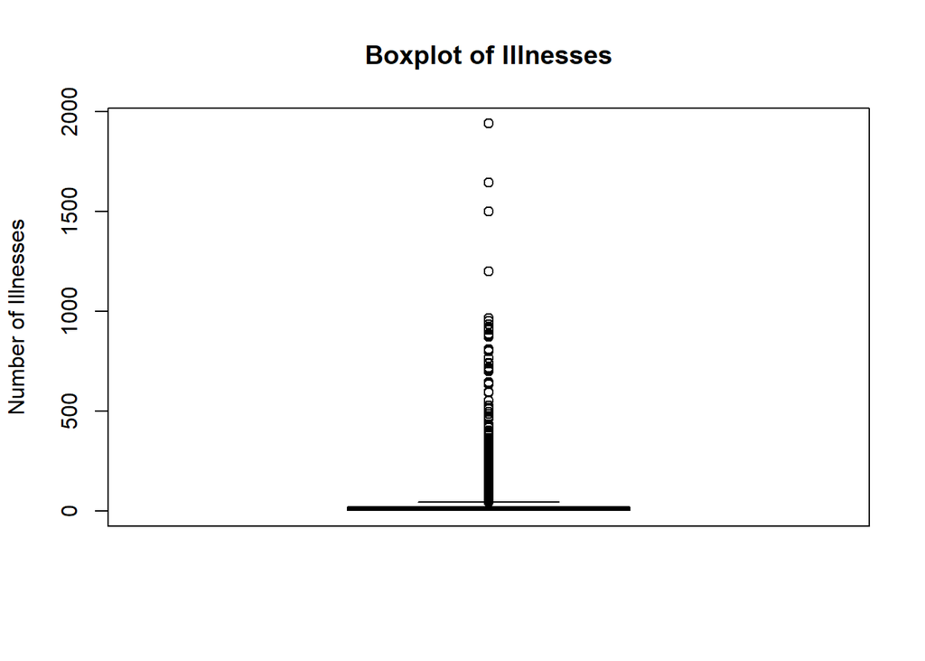

```r
illnesses_bp <- boxplot(outbreaks$Illnesses, main = "Boxplot of Illnesses", ylab = "Number of Illnesses")
```

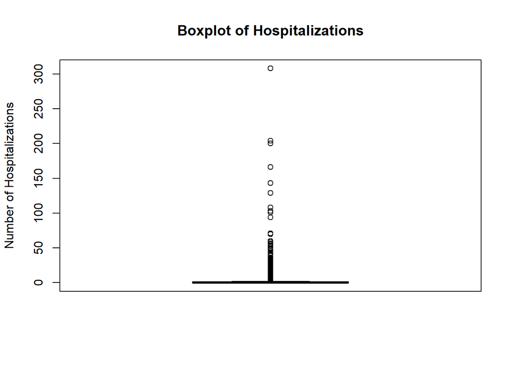

```r
outliers_illnesses <- subset(outbreaks, Illnesses > 43)

hospitalizations_bp <- boxplot(outbreaks$Hospitalizations, main = "Boxplot of Hospitalizations", ylab = "Number of Hospitalizations")
```

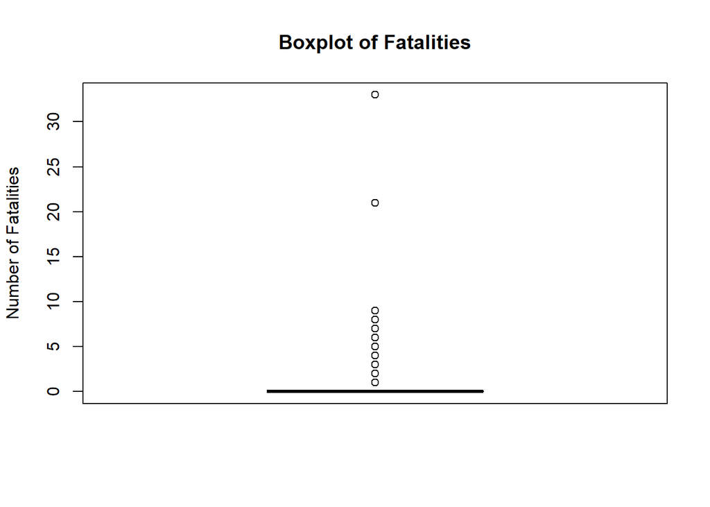

```r
outliers_hospitalizations <- subset(outbreaks, Hospitalizations > 2.5)

fatalities_bp <- boxplot(outbreaks$Fatalities, main = "Boxplot of Fatalities", ylab = "Number of Fatalities")
```

```r
outliers_fatalities <- subset(outbreaks, Fatalities > 0)
```

## EDA

#### Illnesses across the states change in different years.

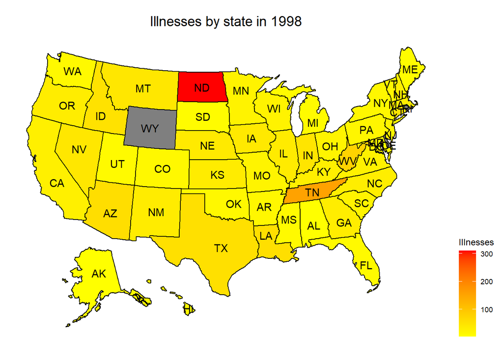

```r
levels(outbreak$State)[levels(outbreak$State)=="Washington DC"] <- "District of Columbia"

# In 1998
ill1998 <- outbreak %>% filter(Year == 1998) %>%
  group_by(State) %>%
  summarise(illness = mean(Illnesses, na.rm=T)) %>%
  left_join(x=statepop, by=c("full"="State")) %>%
  select(fips, abbr, full, illness)
plot_usmap(data=ill1998, values="illness", color=1, labels = T) +
  scale_fill_continuous(name="Illnesses",
                        low = "yellow", high = "red",
                        label=scales::comma) +
  ggtitle(paste0("Illnesses by state in ", 1998)) +
  theme(legend.position = "right",
        plot.title = element_text(hjust = 0.5, size=14))
```

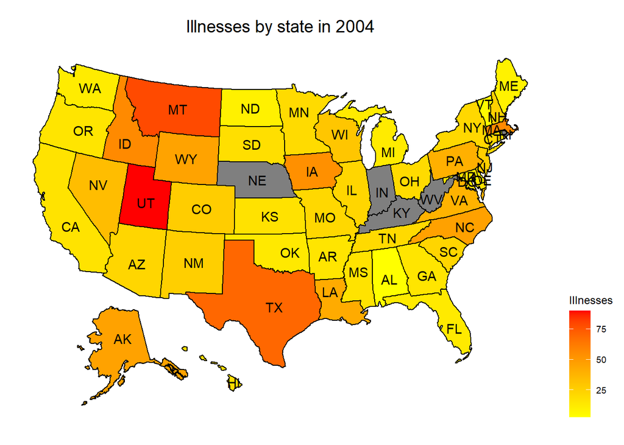

```r
# In 2004
ill2004 <- outbreak %>% filter(Year == 2004) %>%
  group_by(State) %>%
  summarise(illness = mean(Illnesses, na.rm=T)) %>%
  left_join(x=statepop, by=c("full"="State")) %>%
  select(fips, abbr, full, illness)
plot_usmap(data=ill2004, values="illness", color=1, labels = T) +
  scale_fill_continuous(name="Illnesses",
                        low = "yellow", high = "red",
                        label=scales::comma) +
  ggtitle(paste0("Illnesses by state in ", 2004)) +
  theme(legend.position = "right",
        plot.title = element_text(hjust = 0.5, size=14))
```

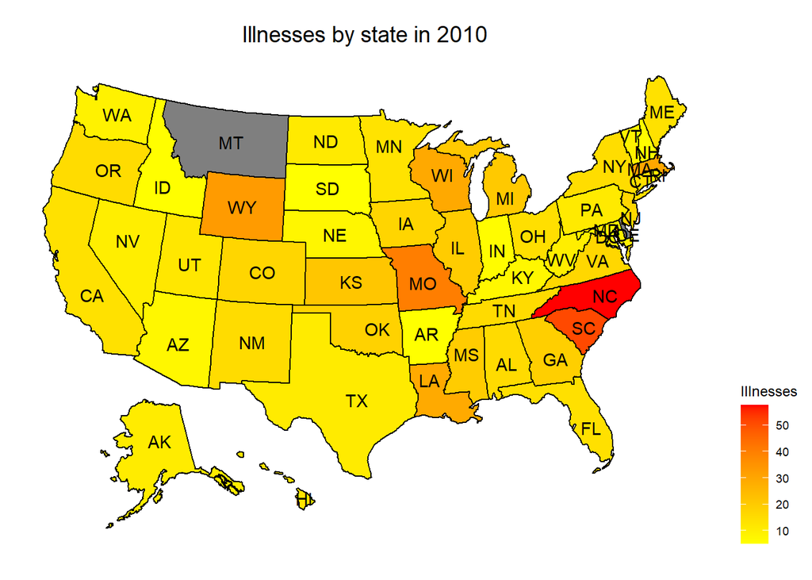

```r
# In 2010
ill2010 <- outbreak %>% filter(Year == 2010) %>%
  group_by(State) %>%
  summarise(illness = mean(Illnesses, na.rm=T)) %>%
  left_join(x=statepop, by=c("full"="State")) %>%
  select(fips, abbr, full, illness)
plot_usmap(data=ill2010, values="illness", color=1, labels = T) +
  scale_fill_continuous(name="Illnesses",
                        low = "yellow", high = "red",
                        label=scales::comma) +
  ggtitle(paste0("Illnesses by state in ", 2010)) +
  theme(legend.position = "right",
        plot.title = element_text(hjust = 0.5, size=14))
```

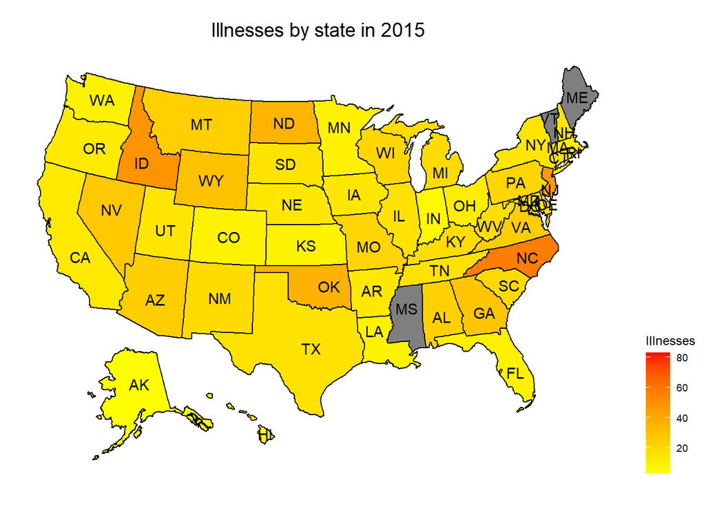

```r
# In 2015
ill2015 <- outbreak %>% filter(Year == 2015) %>%
  group_by(State) %>%
  summarise(illness = mean(Illnesses, na.rm=T)) %>%
  left_join(x=statepop, by=c("full"="State")) %>%
  select(fips, abbr, full, illness)
plot_usmap(data=ill2015, values="illness", color=1, labels = T) +
  scale_fill_continuous(name="Illnesses",
                        low = "yellow", high = "red",
                        label=scales::comma) +
  ggtitle(paste0("Illnesses by state in ", 2015)) +
  theme(legend.position = "right",
        plot.title = element_text(hjust = 0.5, size=14))
```

From the USMAP above, we can clearly see that the maximum number of illnesses has been lowered to 80 from 1998 to 2015. In 1998, the North Dakota has maximum illness around 300; however, in 2004, Montana and Utah has maximum illnesses around 80. In 2010, only North and South Carolina have maximum illnesses around 50, and South Carolina’s illness has been backed to normal (under 20) in 2015.

#### The general trend of foodborne illnesses over the years and months

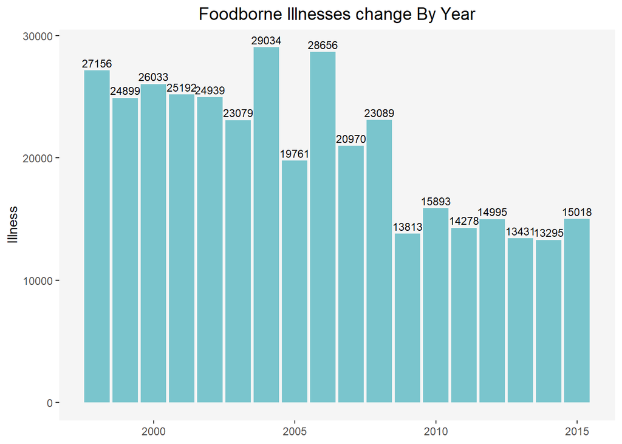

```r
# By year
outbreak %>% group_by(Year) %>%
  summarise(Illness = sum(Illnesses, na.rm=T)) %>%
  ggplot(aes(x = Year, y = Illness)) +
  geom_bar(stat = "identity", fill = "cadetblue3") +
  geom_text(aes(label = Illness), vjust = -0.4, color = "black",size=3) +
  ggtitle("Foodborne Illnesses change By Year") +
  theme(panel.grid.major = element_blank(),
        panel.grid.minor = element_blank(),
        panel.background = element_rect(fill = "gray96"),
        axis.title.x=element_blank(),
        plot.title = element_text(hjust = 0.5, size=14))
```

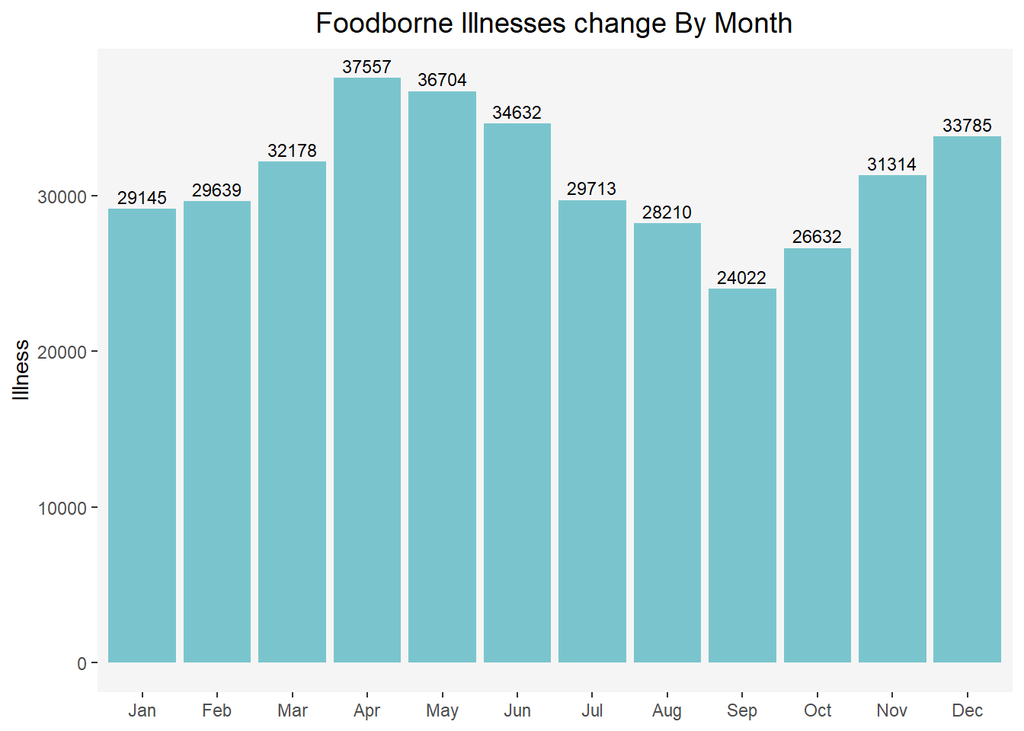

```r
# By Month
outbreak_month <- outbreak %>%
  group_by(Month) %>%
  summarise(Illness = sum(Illnesses, na.rm=T))
outbreak_month$Month <- substr(outbreak_month$Month, 1, 3)
outbreak_month$Month <- factor(outbreak_month$Month, month.abb, ordered=TRUE)

outbreak_month %>%
  ggplot(aes(x = Month, y = Illness)) +
  geom_bar(stat = "identity", fill = "cadetblue3") +
  geom_text(aes(label = Illness), vjust = -0.4, color = "black",size=3) +
  ggtitle("Foodborne Illnesses change By Month") +
  theme(panel.grid.major = element_blank(),
        panel.grid.minor = element_blank(),
        panel.background = element_rect(fill = "gray96"),
        axis.title.x=element_blank(),
        plot.title = element_text(hjust = 0.5, size=14))
```

#### Time series plot of illnesses caused by top4 species

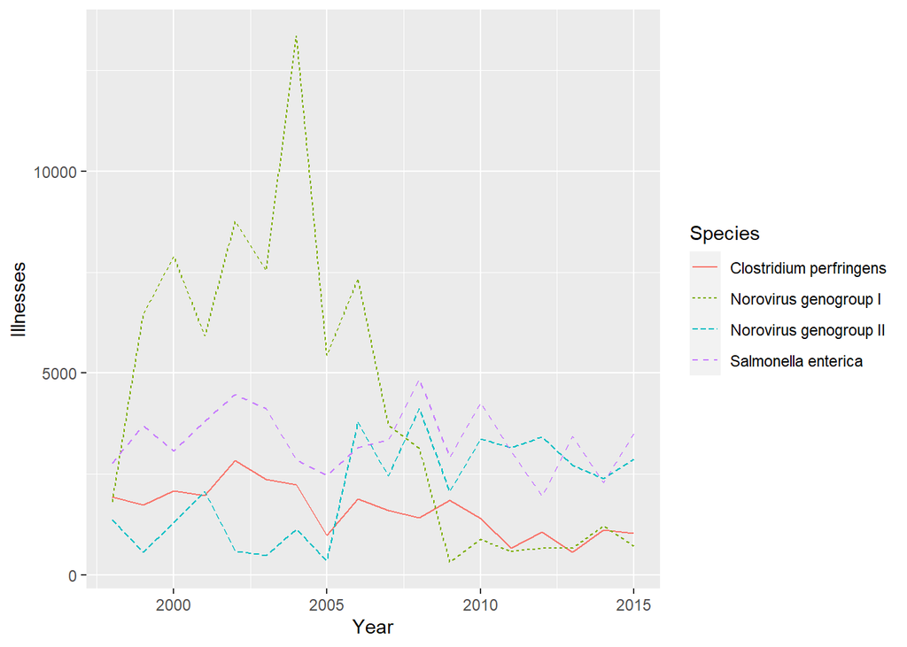

```r
outbreak %>% filter(Species %in% c(
  "Norovirus genogroup I",
  "Salmonella enterica",
  "Norovirus genogroup II",
  "Clostridium perfringens"
)) %>%
  group_by(Year, Species) %>%
  summarise(Illnesses = sum(Illnesses, na.rm=T)) %>%
  ggplot(aes(x=Year, y=Illnesses, lty=Species, col=Species)) +
  geom_line()
```

## Model Building

#### Preprocessing before model building

Before building our models, we needed to do some additional preprocessing to our data in order to get it ready for building informative models. We decided that we would focus on 3 different predictor variables: `Month`, `Food`, and `State`. And hopefully these features would considerably aid us in training models to predict our target variable, `Species`. At this stage in our analysis the dataset, provided us with `Month` as a factor variable with 12 levels, `State` as a factor variable with 55 levels (it included DC and US territories in addition to the 50 states), `Food` as a factor variable with 3128 levels, and `Species` as a factor variable with 202 levels. We believe that the datapoints for Food and Species contained hand entered variable (rather than choosing from a pre-existing list) which opened it up to a lot of variability in responses and would make it harder for the models to classify with so many levels. Additionally, in order to create the decision trees there was a limit of 32 levels and the as is data did not fit those requirements. Thus, we needed to filter down each variable that had a high amount of levels and filter it into more manageable distinctions. While we do recognize that this added bias to our models and especially disadvantaged the variables that were less common in our dataset (as they were put in the “Other” category), we were hoping it would still provide us with meaningful models that were able to classify Species.

I chose not to filter down the `Month` variable as I felt it was not necessary and that it would be more informative to keep it as is than to make up a reasoning on how to group them. To filter the variable I used a function that checked each data point in a given feature for different regex expressions that I specified. For instance for the Food variable I checked for data points that contained “fish”, “salmon”, or “tuna” and if they contained any of those regex expressions they would be classified into the “Fish” level, and so on. For Food I chose overarching categories of different types of food such as chicken, vegetarian, pork, beef etc. For the Species variable I filtered the levels by choosing the most prevalent species in the dataset and choosng those as levels, and the rest were classified into the Other category. And for the States, I used the Koppen climate classification which for the US and its territories, encompasses 4 different climate levels: Tropical, Dry (Arid and Semiarid), Temperate (Mesothermal), and Continental (Microthermal). Some states do have high variation in climate regions, and for those states I chose the level type that encompassed the largest percentage (majority) of land in the state. I also included an “other” level to catch any mis-entered data.

After preprocessing and filtering the data, the `Food` variable had 8 levels, the `Species` variable had 10 levels, the `State` variable had 5 levels, and the `Month` variable which was not altered had 12 levels.

```r
foodCatXform <- function(val) {
  igCase = TRUE
  if ( ( regexpr("vegetarian",val, ignore.case=igCase)>0 || regexpr("vegan",val, ignore.case=igCase)>0 || regexpr("veggie",val, ignore.case=igCase)>0 || regexpr("salad",val, ignore.case=igCase)>0 || regexpr("meatless",val, ignore.case=igCase)>0 )     &&
       !( regexpr("nonvegan",val, ignore.case=igCase)>0 || regexpr("chicken",val, ignore.case=igCase)>0 || regexpr("someOtherLikeVegeButNotReallyException",val, ignore.case=igCase)>0 ) ) {
    return("Vegetarian")
  } else if ( ( regexpr("chick",val, ignore.case=igCase)>0 || regexpr("chicken",val, ignore.case=igCase)>0 ) &&
       !( regexpr("chickpea",val, ignore.case=igCase)>0 || regexpr("someOtherChickenException",val, ignore.case=igCase)>0 ) ) {
    return("Chicken")
  } else if ( ( regexpr("pork",val, ignore.case=igCase)>0 )  ) {
    return("Pork")
  } else if ( ( regexpr("beef",val, ignore.case=igCase)>0 || regexpr("steak",val, ignore.case=igCase)>0 || regexpr("meat",val, ignore.case=igCase)>0 ) &&
       !( regexpr("holy cow",val, ignore.case=igCase)>0 || regexpr("beefless",val, ignore.case=igCase)>0 || regexpr("someOtherChickenException",val, ignore.case=igCase)>0 ) ) {
    return("Beef")
  } else if ( ( regexpr("fish",val, ignore.case=igCase)>0 || regexpr("tuna",val, ignore.case=igCase)>0 || regexpr("salmon",val, ignore.case=igCase)>0  ) ) {
    return("Fish")
  } else if ( ( regexpr("eggs",val, ignore.case=igCase)>0 || regexpr("egg",val, ignore.case=igCase)>0 ) &&
       !( regexpr("eggless",val, ignore.case=igCase)>0 ) ) {
    return("Egg")
  }  else if ( ( regexpr("fruit",val, ignore.case=igCase)>0 || regexpr("strawberry",val, ignore.case=igCase)>0 || regexpr("acai",val, ignore.case=igCase)>0 || regexpr("banana",val, ignore.case=igCase)>0 || regexpr("berries",val, ignore.case=igCase)>0 || regexpr("berry",val, ignore.case=igCase)>0 || regexpr("mango",val, ignore.case=igCase)>0 || regexpr("melon",val, ignore.case=igCase)>0)) {
    return("Fruit")
  }  else {
    return("Others")
  }
}

speciesCatXform <- function(val) {
  igCase = TRUE
  if ( ( regexpr("Norovirus",val, ignore.case=igCase)>0 || regexpr("norovirus",val, ignore.case=igCase)>0 ) ) {
    return("Norovirus")
  } else if ( ( regexpr("Salmonella",val, ignore.case=igCase)>0 ) ){
    return("Salmonella")
  } else if ( ( regexpr("Clostridium perfringens",val, ignore.case=igCase)>0 || regexpr("steak",val, ignore.case=igCase)>0 ) ) {
    return("Clostridium perfringens")
  } else if ( ( regexpr("Staphylococcus",val, ignore.case=igCase)>0)  ) {
    return("Staphylococcus")
  } else if ( ( regexpr("Escherichia coli",val, ignore.case=igCase)>0)  ) {
    return("Escherichia coli")
  } else if ( ( regexpr("Scombroid toxin",val, ignore.case=igCase)>0)  ) {
    return("Scombroid toxin")
  } else if ( ( regexpr("Bacillus cereus",val, ignore.case=igCase)>0)  ) {
    return("Bacillus cereus")
  } else if ( ( regexpr("Campylobacter jejuni",val, ignore.case=igCase)>0)  ) {
    return("Campylobacter jejuni")
  } else if ( ( regexpr("Ciguatoxin",val, ignore.case=igCase)>0)  ) {
    return("Ciguatoxin")
  }     else {
    return("Others")
  }
}

#https://www.plantmaps.com/koppen-climate-classification-map-united-states.php
#https://en.climate-data.org/

stateCatXform <- function(val) {
  igCase = TRUE
  if( regexpr("Alabama",val, ignore.case=igCase)>0 ) {
    return("3")
  } else if ( regexpr("Alaska",val, ignore.case=igCase)>0 ) {
    return("4")
  } else if ( regexpr("Arizona",val, ignore.case=igCase)>0 ) {
    return("2")
  } else if ( ( regexpr("Arkansas",val, ignore.case=igCase)>0)  ) {
    return("3")
  } else if ( ( regexpr("California",val, ignore.case=igCase)>0)  ) {
    return("3")
  } else if ( ( regexpr("Colorado",val, ignore.case=igCase)>0)  ) {
    return("2")
  } else if ( ( regexpr("Connecticut",val, ignore.case=igCase)>0)  ) {
    return("4")
  } else if ( ( regexpr("Delaware",val, ignore.case=igCase)>0)  ) {
    return("3")
  } else if ( ( regexpr("Florida",val, ignore.case=igCase)>0)  ) {
    return("3")
  } else if ( ( regexpr("Georgia",val, ignore.case=igCase)>0)  ) {
    return("3")
  } else if ( ( regexpr("Hawaii",val, ignore.case=igCase)>0)  ) {
    return("1")
  } else if ( ( regexpr("Idaho",val, ignore.case=igCase)>0)  ) {
    return("2")
  } else if ( ( regexpr("Illinois",val, ignore.case=igCase)>0)  ) {
    return("4")
  } else if ( ( regexpr("Indiana",val, ignore.case=igCase)>0)  ) {
    return("4")
  } else if ( ( regexpr("Iowa",val, ignore.case=igCase)>0)  ) {
    return("4")
  } else if ( ( regexpr("Kansas",val, ignore.case=igCase)>0)  ) {
    return("4")
  } else if ( ( regexpr("Kentucky",val, ignore.case=igCase)>0)  ) {
    return("4")
  } else if ( ( regexpr("Louisiana",val, ignore.case=igCase)>0)  ) {
    return("3")
  } else if ( ( regexpr("Maine",val, ignore.case=igCase)>0)  ) {
    return("4")
  } else if ( ( regexpr("Maryland",val, ignore.case=igCase)>0)  ) {
    return("3")
  } else if ( ( regexpr("Massachusetts",val, ignore.case=igCase)>0)  ) {
    return("4")
  } else if ( ( regexpr("Michigan",val, ignore.case=igCase)>0)  ) {
    return("4")
  } else if ( ( regexpr("Minnesota",val, ignore.case=igCase)>0)  ) {
    return("4")
  } else if ( ( regexpr("Mississippi",val, ignore.case=igCase)>0)  ) {
    return("3")
  } else if ( ( regexpr("Missouri",val, ignore.case=igCase)>0)  ) {
    return("4")
  } else if ( ( regexpr("Montana",val, ignore.case=igCase)>0)  ) {
    return("2")
  } else if ( ( regexpr("Nebraska",val, ignore.case=igCase)>0)  ) {
    return("4")
  } else if ( ( regexpr("Nevada",val, ignore.case=igCase)>0)  ) {
    return("2")
  } else if ( ( regexpr("New Hampshire",val, ignore.case=igCase)>0)  ) {
    return("4")
  } else if ( ( regexpr("New Jersey",val, ignore.case=igCase)>0)  ) {
    return("4")
  } else if ( ( regexpr("New Mexico",val, ignore.case=igCase)>0)  ) {
    return("2")
  } else if ( ( regexpr("New York",val, ignore.case=igCase)>0)  ) {
    return("4")
  } else if ( ( regexpr("North Carolina",val, ignore.case=igCase)>0)  ) {
    return("3")
  } else if ( ( regexpr("North Dakota",val, ignore.case=igCase)>0)  ) {
    return("4")
  } else if ( ( regexpr("Ohio",val, ignore.case=igCase)>0)  ) {
    return("4")
  } else if ( ( regexpr("Oklahoma",val, ignore.case=igCase)>0)  ) {
    return("3")
  } else if ( ( regexpr("Oregon",val, ignore.case=igCase)>0)  ) {
    return("3")
  } else if ( ( regexpr("Pennsylvania",val, ignore.case=igCase)>0)  ) {
    return("4")
  } else if ( ( regexpr("Rhode Island",val, ignore.case=igCase)>0)  ) {
    return("4")
  } else if ( ( regexpr("South Carolina",val, ignore.case=igCase)>0)  ) {
    return("3")
  } else if ( ( regexpr("South Dakota",val, ignore.case=igCase)>0)  ) {
    return("4")
  } else if ( ( regexpr("Tennessee",val, ignore.case=igCase)>0)  ) {
    return("3")
  } else if ( ( regexpr("Texas",val, ignore.case=igCase)>0)  ) {
    return("3")
  } else if ( ( regexpr("Utah",val, ignore.case=igCase)>0)  ) {
    return("4")
  } else if ( ( regexpr("Vermont",val, ignore.case=igCase)>0)  ) {
    return("4")
  } else if ( ( regexpr("Virginia",val, ignore.case=igCase)>0)  ) {
    return("3")
  } else if ( ( regexpr("Washington",val, ignore.case=igCase)>0)  ) {
    return("3")
  } else if ( ( regexpr("West Virginia",val, ignore.case=igCase)>0)  ) {
    return("4")
  } else if ( ( regexpr("Wisconsin",val, ignore.case=igCase)>0)  ) {
    return("4")
  } else if ( ( regexpr("Wyoming",val, ignore.case=igCase)>0)  ) {
    return("2")
  } else if ( ( regexpr("District of Columbia",val, ignore.case=igCase)>0 || regexpr("DC",val, ignore.case=igCase)>0 ) || regexpr("D.C.",val, ignore.case=igCase)>0 ) {
    return("3")
  } else if ( ( regexpr("American Samoa",val, ignore.case=igCase)>0) || regexpr("Samoa",val, ignore.case=igCase)>0 ) {
    return("1")
  } else if ( ( regexpr("Guam",val, ignore.case=igCase)>0)  ) {
    return("1")
  } else if ( ( regexpr("Mariana",val, ignore.case=igCase)>0)  ) {
    return("1")
  } else if ( ( regexpr("Puerto Rico",val, ignore.case=igCase)>0) || regexpr("PR",val, ignore.case=igCase)>0 ) {
    return("1")
  } else if ( ( regexpr("Virgin Islands",val, ignore.case=igCase)>0) || regexpr("US Virgin Islands",val, ignore.case=igCase)>0 ) {
    return("1")
  }     else {
    return("Others")
  }
}
```

```r
out = outbreaks[c(2:5, 7)]
#str(out)

out$filterFood = sapply(out$Food, FUN = foodCatXform )
out$filterSpecies = sapply(out$Species, FUN = speciesCatXform )
out$filterState = sapply(out$State, FUN = stateCatXform )
#str(out)
out$filterFood = factor(out$filterFood)
out$filterSpecies = factor(out$filterSpecies)
out$filterState = factor(out$filterState)

#koppen climate classification for states
# https://www.plantmaps.com/koppen-climate-classification-map-united-states.php

#str(out)
#summary(out)
```

```r
# This is the final data set that includes Species (as the response) and Food, State, and Month (as predictors)

model_data = data.frame(out[,c("Month", "filterFood", "filterSpecies", "filterState")])

head(model_data)
```

## K-Nearest Neighbors

```r
loadPkg(xtable)
loadPkg(kableExtra)
loadPkg(stringi)
#str(model_data)
#xkablesummary(model_data)
```

We can see from the histograms below that each of the feature variable are not normally distributed. The Species variable has a left skew.

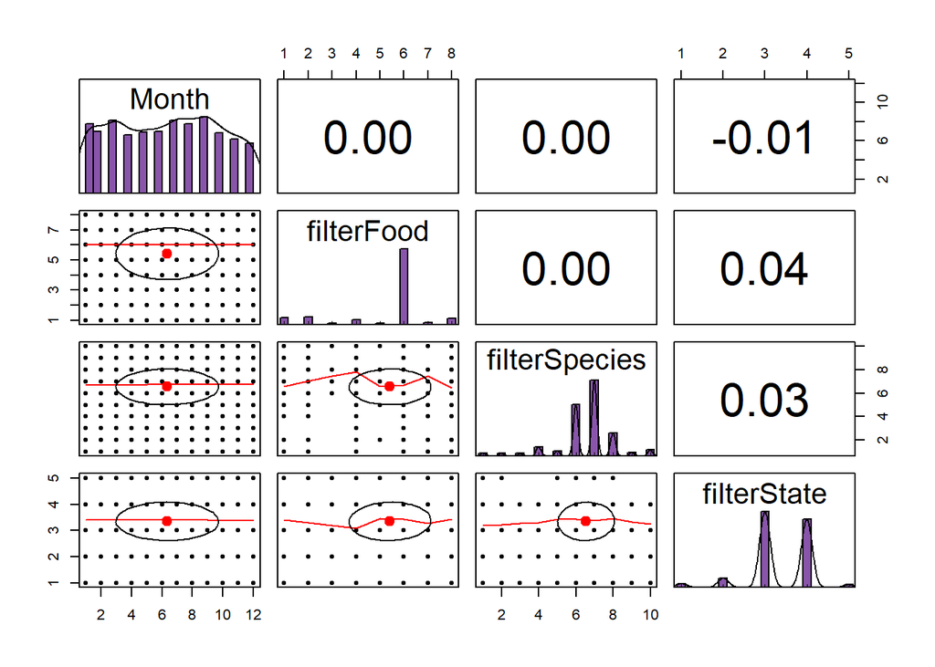

```r
loadPkg(psych)
pairs.panels(model_data,
             method = "pearson", # correlation method
             hist.col = "#8855aa", # set histogram color, can use "#22AFBB", "red",
             density = TRUE,  # show density plots
             ellipses = TRUE # show correlation ellipses
             )
```

```r
unloadPkg(psych)
```

First, I needed to do some additional preprocessing before executing KNN. The R KNN function requires numerical data, and since our feature variables were all categorical at this point, I chose to map each factor level to a number and then run KNN. It was not necessary to map the Species variable as it was the target variable.

```r
num_model <- model_data
loadPkg(plyr)

num_model$numMonth <- (mapvalues(num_model$Month,
          from=c("January","February","March", "April", "May", "June", "July", "August", "September", "October", "November", "December"),
          to=c(1,2,3, 4, 5, 6, 7, 8, 9, 10, 11, 12)))

num_model$numFood <- (mapvalues(num_model$filterFood,
          from=c("Beef","Chicken","Egg", "Fish", "Fruit", "Others", "Pork", "Vegetarian"),
          to=c(1,2,3, 4, 5, 6, 7, 8)))

num_model$numState <- as.numeric(as.character(num_model$filterState))

#num_model$numSpecies <- (mapvalues(num_model$filterSpecies,
#          from=c("Bacillus cereus","Campylobacter jejuni","Ciguatoxin", "Ciguatoxin", "Escherichia coli", "Norovirus", "Others", #"Salmonella", "Scombroid toxin", "Staphylococcus"),
#          to=c(1,2,3, 4, 5, 6, 7, 8, 9, 10)))
num_model$numMonth <- as.numeric(as.character(num_model$numMonth))
num_model$numFood <- as.numeric(as.character(num_model$numFood))
#num_model$numSpecies <- as.numeric(as.character(num_model$numSpecies))
num_model$numSpecies <- num_model$filterSpecies

head(num_model)
```

```r
mapped <- subset(num_model, select = c(5, 6, 7, 8))
mapped <- (na.omit(mapped))

zmapped <- subset(mapped, select = c(1, 2, 3))
zmapped
```

```r
#scale
zmapped <- as.data.frame(scale(zmapped, center = TRUE, scale = TRUE))

set.seed(1)
splitarray <- sample(2, nrow(zmapped), replace=TRUE, prob=c(0.75, 0.25))

zmapped_Xtrain <- zmapped[splitarray==1, 1:3] # dataframe
zmapped_Xtest <- zmapped[splitarray==2, 1:3] # dataframe
zmapped_ytrain <- mapped[splitarray==1, 4] #  1-D array
zmapped_ytest <- mapped[splitarray==2,4] # 1-D array
#length(zmapped_ytrain)
#length(zmapped_ytest)
```

We ended up with 14046 data points in the train set, and 4732 data points in the test set.

Next, I ran knn and initially looped through the k-values from 3 to 21, but here we will show the confusion matrix from 3 to 7 for a better visual representation and looked at the accuracy, precision, recall, F1 and other metrics using the confusion matrix to determine the best k value.

```r
loadPkg(gmodels)
loadPkg(FNN)
loadPkg(caret)

# create an empty dataframe to store the results from confusion matrices
confusionMatrixResultDf = data.frame( k=numeric(0), Accuracy= numeric(0), Sensitivity=numeric(0), Specificity=numeric(0), Pos.Pred.Value=numeric(0), Neg.Pred.Value=numeric(0), Precision=numeric(0), Recall=numeric(0), F1=numeric(0), Prevalence=numeric(0), Detection.Rate=numeric(0), Detection.Prevalence=numeric(0), Balanced.Accuracy=numeric(0), row.names = NULL )

for (kval in 3:7) {
  MappedPredict <- knn(train = zmapped_Xtrain, test = zmapped_Xtest, cl=zmapped_ytrain, k=kval)
  mappedXtable <- CrossTable(zmapped_ytest, MappedPredict, prop.chisq = FALSE)
  print( paste("k = ", kval) )
  mappedXtable
  #
  cm = confusionMatrix(MappedPredict, reference = zmapped_ytest ) # from caret library
  #
  cmaccu = cm$overall['Accuracy']
  print( paste("Total Accuracy = ", cmaccu ) )
  #
  cmt = data.frame(k=kval, Accuracy = cmaccu, row.names = NULL ) # initialize a row of the metrics
  cmt = cbind( cmt, data.frame( t(cm$byClass) ) ) # the dataframe of the transpose, with k valued added in front
  confusionMatrixResultDf = rbind(confusionMatrixResultDf, cmt)
  # print("Other metrics : ")
}
```

```r
xkabledply(confusionMatrixResultDf)
```

Table

|  | k | Accuracy | Class..Bacillus.cereus | Class..Campylobacter.jejuni | Class..Ciguatoxin | Class..Clostridium.perfringens | Class..Escherichia.coli | Class..Norovirus | Class..Others | Class..Salmonella | Class..Scombroid.toxin | Class..Staphylococcus |
| --- | --- | --- | --- | --- | --- | --- | --- | --- | --- | --- | --- | --- |
| Sensitivity | 3 | 0.312 | 0.0411 | 0.0323 | 0.3973 | 0.1753 | 0.0336 | 0.462 | 0.335 | 0.1107 | 0.3956 | 0.0629 |
| Specificity | 3 | 0.312 | 0.9431 | 0.9893 | 0.9873 | 0.8842 | 0.9920 | 0.660 | 0.683 | 0.9535 | 0.9892 | 0.9864 |
| Pos Pred Value | 3 | 0.312 | 0.0112 | 0.0385 | 0.3295 | 0.0782 | 0.0976 | 0.344 | 0.442 | 0.2422 | 0.4186 | 0.1389 |
| Neg Pred Value | 3 | 0.312 | 0.9843 | 0.9872 | 0.9905 | 0.9503 | 0.9755 | 0.761 | 0.578 | 0.8887 | 0.9882 | 0.9680 |
| Precision | 3 | 0.312 | 0.0112 | 0.0385 | 0.3295 | 0.0782 | 0.0976 | 0.344 | 0.442 | 0.2422 | 0.4186 | 0.1389 |
| Recall | 3 | 0.312 | 0.0411 | 0.0323 | 0.3973 | 0.1753 | 0.0336 | 0.462 | 0.335 | 0.1107 | 0.3956 | 0.0629 |
| F1 | 3 | 0.312 | 0.0176 | 0.0351 | 0.3602 | 0.1081 | 0.0500 | 0.394 | 0.381 | 0.1520 | 0.4068 | 0.0866 |
| Prevalence | 3 | 0.312 | 0.0154 | 0.0131 | 0.0154 | 0.0530 | 0.0251 | 0.278 | 0.428 | 0.1183 | 0.0192 | 0.0336 |
| Detection Rate | 3 | 0.312 | 0.0006 | 0.0004 | 0.0061 | 0.0093 | 0.0008 | 0.129 | 0.143 | 0.0131 | 0.0076 | 0.0021 |
| Detection Prevalence | 3 | 0.312 | 0.0566 | 0.0110 | 0.0186 | 0.1190 | 0.0087 | 0.374 | 0.324 | 0.0541 | 0.0182 | 0.0152 |
| Balanced Accuracy | 3 | 0.312 | 0.4921 | 0.5108 | 0.6923 | 0.5297 | 0.5128 | 0.561 | 0.509 | 0.5321 | 0.6924 | 0.5247 |
| Sensitivity1 | 4 | 0.362 | 0.0274 | 0.0000 | 0.5068 | 0.0956 | 0.0420 | 0.626 | 0.354 | 0.1357 | 0.2637 | 0.0189 |
| Specificity1 | 4 | 0.362 | 0.9775 | 0.9884 | 0.9869 | 0.9763 | 0.9967 | 0.552 | 0.682 | 0.9492 | 0.9918 | 0.9915 |
| Pos Pred Value1 | 4 | 0.362 | 0.0187 | 0.0000 | 0.3776 | 0.1846 | 0.2500 | 0.350 | 0.455 | 0.2639 | 0.3871 | 0.0714 |
| Neg Pred Value1 | 4 | 0.362 | 0.9846 | 0.9867 | 0.9922 | 0.9507 | 0.9758 | 0.793 | 0.585 | 0.8911 | 0.9857 | 0.9667 |
| Precision1 | 4 | 0.362 | 0.0187 | 0.0000 | 0.3776 | 0.1846 | 0.2500 | 0.350 | 0.455 | 0.2639 | 0.3871 | 0.0714 |
| Recall1 | 4 | 0.362 | 0.0274 | 0.0000 | 0.5068 | 0.0956 | 0.0420 | 0.626 | 0.354 | 0.1357 | 0.2637 | 0.0189 |
| F11 | 4 | 0.362 | 0.0222 | NaN | 0.4327 | 0.1260 | 0.0719 | 0.450 | 0.398 | 0.1792 | 0.3137 | 0.0299 |
| Prevalence1 | 4 | 0.362 | 0.0154 | 0.0131 | 0.0154 | 0.0530 | 0.0251 | 0.278 | 0.428 | 0.1183 | 0.0192 | 0.0336 |
| Detection Rate1 | 4 | 0.362 | 0.0004 | 0.0000 | 0.0078 | 0.0051 | 0.0011 | 0.174 | 0.151 | 0.0161 | 0.0051 | 0.0006 |
| Detection Prevalence1 | 4 | 0.362 | 0.0226 | 0.0114 | 0.0207 | 0.0275 | 0.0042 | 0.497 | 0.333 | 0.0609 | 0.0131 | 0.0089 |
| Balanced Accuracy1 | 4 | 0.362 | 0.5024 | 0.4942 | 0.7469 | 0.5360 | 0.5194 | 0.589 | 0.518 | 0.5424 | 0.6278 | 0.5052 |
| Sensitivity2 | 5 | 0.385 | 0.0000 | 0.0000 | 0.4658 | 0.0916 | 0.0420 | 0.607 | 0.433 | 0.0964 | 0.2857 | 0.0063 |
| Specificity2 | 5 | 0.385 | 0.9972 | 0.9996 | 0.9878 | 0.9790 | 0.9946 | 0.551 | 0.609 | 0.9832 | 0.9912 | 0.9954 |
| Pos Pred Value2 | 5 | 0.385 | 0.0000 | 0.0000 | 0.3736 | 0.1966 | 0.1667 | 0.343 | 0.454 | 0.4355 | 0.3881 | 0.0455 |
| Neg Pred Value2 | 5 | 0.385 | 0.9845 | 0.9869 | 0.9916 | 0.9506 | 0.9758 | 0.785 | 0.589 | 0.8902 | 0.9861 | 0.9665 |
| Precision2 | 5 | 0.385 | 0.0000 | 0.0000 | 0.3736 | 0.1966 | 0.1667 | 0.343 | 0.454 | 0.4355 | 0.3881 | 0.0455 |
| Recall2 | 5 | 0.385 | 0.0000 | 0.0000 | 0.4658 | 0.0916 | 0.0420 | 0.607 | 0.433 | 0.0964 | 0.2857 | 0.0063 |
| F12 | 5 | 0.385 | NaN | NaN | 0.4146 | 0.1250 | 0.0671 | 0.438 | 0.443 | 0.1579 | 0.3291 | 0.0110 |
| Prevalence2 | 5 | 0.385 | 0.0154 | 0.0131 | 0.0154 | 0.0530 | 0.0251 | 0.278 | 0.428 | 0.1183 | 0.0192 | 0.0336 |
| Detection Rate2 | 5 | 0.385 | 0.0000 | 0.0000 | 0.0072 | 0.0049 | 0.0011 | 0.169 | 0.185 | 0.0114 | 0.0055 | 0.0002 |
| Detection Prevalence2 | 5 | 0.385 | 0.0027 | 0.0004 | 0.0192 | 0.0247 | 0.0063 | 0.493 | 0.409 | 0.0262 | 0.0142 | 0.0046 |
| Balanced Accuracy2 | 5 | 0.385 | 0.4986 | 0.4998 | 0.7268 | 0.5353 | 0.5183 | 0.579 | 0.521 | 0.5398 | 0.6384 | 0.5008 |
| Sensitivity3 | 6 | 0.386 | 0.0000 | 0.0000 | 0.4247 | 0.0956 | 0.0420 | 0.601 | 0.429 | 0.1268 | 0.3956 | 0.0063 |
| Specificity3 | 6 | 0.386 | 0.9974 | 1.0000 | 0.9903 | 0.9772 | 0.9944 | 0.578 | 0.627 | 0.9494 | 0.9894 | 0.9978 |
| Pos Pred Value3 | 6 | 0.386 | 0.0000 | NaN | 0.4079 | 0.1905 | 0.1613 | 0.354 | 0.463 | 0.2518 | 0.4235 | 0.0909 |
| Neg Pred Value3 | 6 | 0.386 | 0.9845 | 0.9869 | 0.9910 | 0.9507 | 0.9757 | 0.790 | 0.594 | 0.8901 | 0.9882 | 0.9665 |
| Precision3 | 6 | 0.386 | 0.0000 | NA | 0.4079 | 0.1905 | 0.1613 | 0.354 | 0.463 | 0.2518 | 0.4235 | 0.0909 |
| Recall3 | 6 | 0.386 | 0.0000 | 0.0000 | 0.4247 | 0.0956 | 0.0420 | 0.601 | 0.429 | 0.1268 | 0.3956 | 0.0063 |
| F13 | 6 | 0.386 | NaN | NA | 0.4161 | 0.1273 | 0.0667 | 0.446 | 0.445 | 0.1686 | 0.4091 | 0.0118 |
| Prevalence3 | 6 | 0.386 | 0.0154 | 0.0131 | 0.0154 | 0.0530 | 0.0251 | 0.278 | 0.428 | 0.1183 | 0.0192 | 0.0336 |
| Detection Rate3 | 6 | 0.386 | 0.0000 | 0.0000 | 0.0066 | 0.0051 | 0.0011 | 0.167 | 0.184 | 0.0150 | 0.0076 | 0.0002 |
| Detection Prevalence3 | 6 | 0.386 | 0.0025 | 0.0000 | 0.0161 | 0.0266 | 0.0066 | 0.471 | 0.397 | 0.0596 | 0.0180 | 0.0023 |
| Balanced Accuracy3 | 6 | 0.386 | 0.4987 | 0.5000 | 0.7075 | 0.5364 | 0.5182 | 0.590 | 0.528 | 0.5381 | 0.6925 | 0.5021 |
| Sensitivity4 | 7 | 0.389 | 0.0000 | 0.0000 | 0.4110 | 0.1036 | 0.0420 | 0.559 | 0.456 | 0.1357 | 0.4505 | 0.0063 |
| Specificity4 | 7 | 0.389 | 0.9979 | 1.0000 | 0.9923 | 0.9788 | 0.9944 | 0.602 | 0.599 | 0.9463 | 0.9879 | 0.9993 |
| Pos Pred Value4 | 7 | 0.389 | 0.0000 | NaN | 0.4545 | 0.2149 | 0.1613 | 0.351 | 0.460 | 0.2533 | 0.4227 | 0.2500 |
| Neg Pred Value4 | 7 | 0.389 | 0.9845 | 0.9869 | 0.9908 | 0.9512 | 0.9757 | 0.780 | 0.595 | 0.8908 | 0.9892 | 0.9666 |
| Precision4 | 7 | 0.389 | 0.0000 | NA | 0.4545 | 0.2149 | 0.1613 | 0.351 | 0.460 | 0.2533 | 0.4227 | 0.2500 |
| Recall4 | 7 | 0.389 | 0.0000 | 0.0000 | 0.4110 | 0.1036 | 0.0420 | 0.559 | 0.456 | 0.1357 | 0.4505 | 0.0063 |
| F14 | 7 | 0.389 | NaN | NA | 0.4317 | 0.1398 | 0.0667 | 0.431 | 0.458 | 0.1767 | 0.4362 | 0.0123 |
| Prevalence4 | 7 | 0.389 | 0.0154 | 0.0131 | 0.0154 | 0.0530 | 0.0251 | 0.278 | 0.428 | 0.1183 | 0.0192 | 0.0336 |
| Detection Rate4 | 7 | 0.389 | 0.0000 | 0.0000 | 0.0063 | 0.0055 | 0.0011 | 0.155 | 0.196 | 0.0161 | 0.0087 | 0.0002 |
| Detection Prevalence4 | 7 | 0.389 | 0.0021 | 0.0000 | 0.0139 | 0.0256 | 0.0066 | 0.442 | 0.425 | 0.0634 | 0.0205 | 0.0008 |
| Balanced Accuracy4 | 7 | 0.389 | 0.4989 | 0.5000 | 0.7016 | 0.5412 | 0.5182 | 0.581 | 0.528 | 0.5410 | 0.7192 | 0.5028 |

```r
# I realized that the chooseK function graph does not show an accurate representation of the accuracy as with some k values, the test set doesnt identify one of the species levels which messes up the accuracy calculation.

chooseK = function(k, train_set, val_set, train_class, val_class){
  # Build knn with k neighbors considered.
  set.seed(1)
  class_knn = knn(train = train_set,    #<- training set cases
                  test = val_set,       #<- test set cases
                  cl = train_class,     #<- category for classification
                  k = k) #,                #<- number of neighbors considered
                  # use.all = TRUE)       #<- control ties between class assignments
                                        #   If true, all distances equal to the kth
                                        #   largest are included
  tab = table(class_knn, val_class)
  # Calculate the accuracy.
  accu = sum(tab[row(tab) == col(tab)]) / sum(tab)
  cbind(k = k, accuracy = accu)
}
# The sapply() function plugs in several values into our chooseK function.
# function(x)[function] allows you to apply a series of numbers
# to a function without running a for() loop.
knn_different_k = sapply(seq(1, 21, by = 2),  #<- set k to be odd number from 1 to 21
                         function(x) chooseK(x,
                                             train_set = zmapped_Xtrain,
                                             val_set = zmapped_Xtest,
                                             train_class = zmapped_ytrain,
                                             val_class = zmapped_ytest))
str(knn_different_k)
knn_different_k = data.frame(k = knn_different_k[1,],
                             accuracy = knn_different_k[2,])
loadPkg(ggplot2)
#ggplot(knn_different_k,
#       aes(x = k, y = accuracy)) +
#  geom_line(color = "orange", size = 1.5) +
#  geom_point(size = 3)
```

```r
x <- knn(train = zmapped_Xtrain, test = zmapped_Xtest, cl=zmapped_ytrain, k=5)
x6 <- knn(train = zmapped_Xtrain, test = zmapped_Xtest, cl=zmapped_ytrain, k=6)

#summary(x)
summary(zmapped_ytrain)
#x6 <- factor(x6, levels=c("Bacillus cereus","Campylobacter jejuni","Ciguatoxin", "Ciguatoxin", "Escherichia coli", "Norovirus", "Others", "Salmonella", "Scombroid toxin", "Staphylococcus"))

#summary(zmapped_ytest)
m <- mean(x == zmapped_ytest)
m
#zmapped_ytest
#c("Bacillus cereus","Campylobacter jejuni","Ciguatoxin", "Ciguatoxin", "Escherichia coli", "Norovirus", "Others", #"Salmonella", "Scombroid toxin", "Staphylococcus")
```

If we look at the k=5 value in the confusion matrix, there are a few things I noticed that we would like to highlight. For balanced accuracy the Ciguatoxin came at 72.7% and Scombroid toxin has 63.8% and the rest of the features had roughly 50% balanced accuracy. And for the F1 scores, Ciguatoxin had 41.5% and Norovirus has 43.9% and Scombroid toxin has 32.9%. Looking at these values especially, we were able to conclude that KNN was able to classify Ciguatoxin and Scombroid toxin the most reliably and had trouble with the other causative agents but did have some success.

## Decision Trees

Decision trees are easily understood and interpreted. They are also easily able to use both quantitative and qualitative variables without having to make dummy variables. Here, both a basic decision tree and a Random Forest were used to model the data. A basic decision tree was used first, then a Random Forest, which makes use of the bootstrap method. Additionally, the constructed trees in the forest are decorrelated by using only a random sample of the predictors and not all of them. (James, 2013)

```r
n <- nrow(model_data)
n_train <- round(0.75 * n)
set.seed(1)
train_indices <- sample(1:n, n_train)
dt_train <- model_data[train_indices, ]
dt_test <- model_data[-train_indices, ]
```

#### Basic Decision Tree

```r
# basic decision tree with default parameters
tree.outbreaks = tree(filterSpecies~.,dt_train)
tree.pred = predict(tree.outbreaks,dt_test,type="class")
table(tree.pred,dt_test$filterSpecies) # confusion matrix
mean(tree.pred==dt_test$filterSpecies) # gives accuracy


cm = confusionMatrix(tree.pred, dt_test$filterSpecies)
print('Overall: ')
cm$overall
print('Class: ')
cm$byClass
```

To start the classification process using a decision tree, a basic decision tree was used. No optimization of parameters was initially done, meaning that all parameters were considered at each split, the size of the forest was at default, and no splitting criterion was set. This basic decision tree had an overall accuracy of only 41.3%. Additionally, the sensitivity was 0% for all species except Scombroid toxin producing bacteria and those falling into the “Other” category. The sensitivity for The Scombroid toxin producing bacteria was at 80.4%. What this means is that the algorithm was able to correctly identify the Scombroid toxin producing bacteria 80.4% of the time but did not classify the other bacteria (Bacillus, Campylobacter, etc.) correctly. The specificity was at 100% for all except those falling into the Scombroid toxin producing bacteria, in which it was 97.6% and those falling into the “Others” category at 5.2%. This means that the algorithm did not incorrectly classify a species into a category that was not meant to go into that category at a rate of 100% for all except Scombroid toxin producing bacteria and the others.

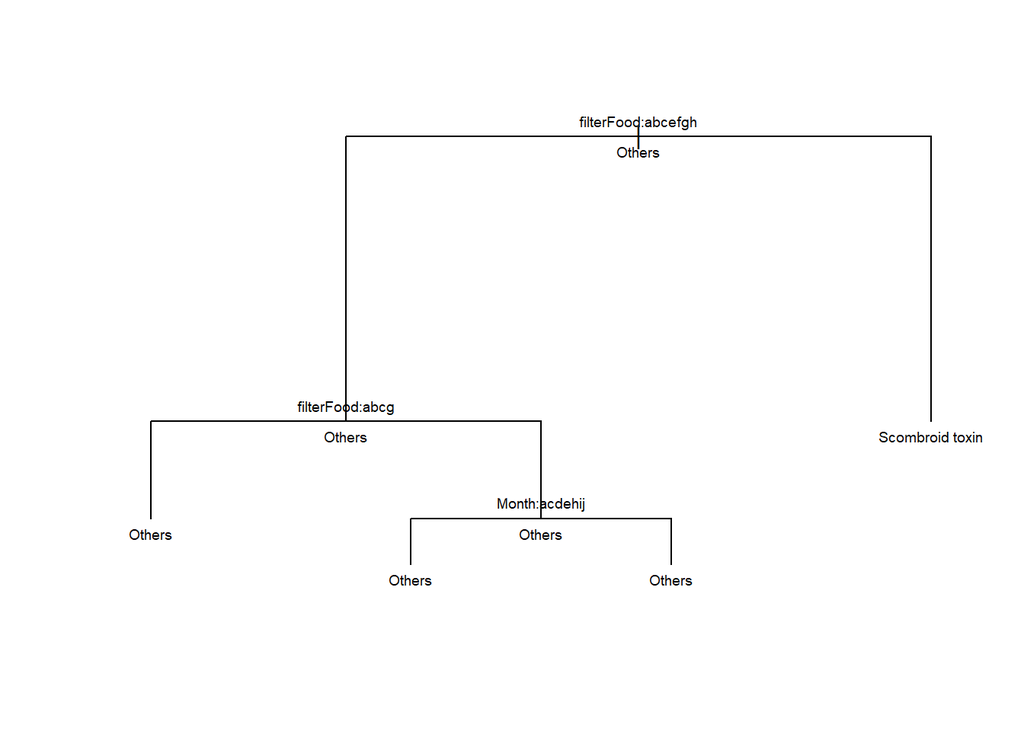

```r
summary(tree.outbreaks)
plot(tree.outbreaks, uniform=TRUE, main="Classification Tree for Species")
text(tree.outbreaks, use.n=TRUE, all=TRUE, cex=.6)
```

```r
###Use another algorithm to see if the basic tree gets any better

set.seed(1)
dt_rout <- rpart(filterSpecies ~ ., data=dt_train, method="class", control = list(maxdepth = 4) )
rout_pred = predict(dt_rout, newdata=dt_test,type = "class")
cm2 = confusionMatrix( rout_pred, dt_test$filterSpecies)
print('Overall: ')
cm2$overall
print('Class: ')
cm2$byClass

#it is the same
```

A secondary algorithm with the same principles and capabilities of the first were compared to determine if one would outperform the other. The function used above is that of tree(). The second function used was rpat(). Both functions returned the same accuracy of 41.3%.

The depth of the tree was then changed to determine if this could increase the predictive capabilities of the tree. Changing the depth of the tree had no impact whatsoever on the accuracy, sensitivity, or specificity the tree, neither within class or between.

```r
confusionMatrixResultDf = data.frame( Depth=numeric(0), Accuracy= numeric(0), Sensitivity=numeric(0), Specificity=numeric(0), Pos.Pred.Value=numeric(0), Neg.Pred.Value=numeric(0), Precision=numeric(0), Recall=numeric(0), F1=numeric(0), Prevalence=numeric(0), Detection.Rate=numeric(0), Detection.Prevalence=numeric(0), Balanced.Accuracy=numeric(0), row.names = NULL )

for (deep in 2:4) {
  sfit <- rpart(filterSpecies ~ ., data=dt_train, method="class", control = list(maxdepth = deep) )
  spred = predict(sfit, newdata=dt_test, type="class")
  #
  cm = confusionMatrix(spred, dt_test$filterSpecies) # from caret library
  #
  cmaccu = cm$overall['Accuracy']
  # print( paste("Total Accuracy = ", cmaccu ) )
  #
  cmt = data.frame(Depth=deep, Accuracy = cmaccu, row.names = NULL ) # initialize a row of the metrics
  cmt = cbind( cmt, data.frame( t(cm$byClass) ) ) # the dataframe of the transpose, with k valued added in front
  confusionMatrixResultDf = rbind(confusionMatrixResultDf, cmt)
}
```

```r
xkabledply(confusionMatrixResultDf, "Classification of Food Poisoning Causative Agent")
```

Classification of Food Poisoning Causative Agent

|  | Depth | Accuracy | Class..Bacillus.cereus | Class..Campylobacter.jejuni | Class..Ciguatoxin | Class..Clostridium.perfringens | Class..Escherichia.coli | Class..Norovirus | Class..Others | Class..Salmonella | Class..Scombroid.toxin | Class..Staphylococcus |
| --- | --- | --- | --- | --- | --- | --- | --- | --- | --- | --- | --- | --- |
| Sensitivity | 2 | 0.413 | 0.0000 | 0.0000 | 0.0000 | 0.0000 | 0.0000 | 0.000 | 0.9779 | 0.000 | 0.8043 | 0.0000 |
| Specificity | 2 | 0.413 | 1.0000 | 1.0000 | 1.0000 | 1.0000 | 1.0000 | 1.000 | 0.0515 | 1.000 | 0.9755 | 1.0000 |
| Pos Pred Value | 2 | 0.413 | NaN | NaN | NaN | NaN | NaN | NaN | 0.4139 | NaN | 0.3915 | NaN |
| Neg Pred Value | 2 | 0.413 | 0.9822 | 0.9856 | 0.9872 | 0.9487 | 0.9766 | 0.711 | 0.7725 | 0.868 | 0.9961 | 0.9665 |
| Precision | 2 | 0.413 | NA | NA | NA | NA | NA | NA | 0.4139 | NA | 0.3915 | NA |
| Recall | 2 | 0.413 | 0.0000 | 0.0000 | 0.0000 | 0.0000 | 0.0000 | 0.000 | 0.9779 | 0.000 | 0.8043 | 0.0000 |
| F1 | 2 | 0.413 | NA | NA | NA | NA | NA | NA | 0.5816 | NA | 0.5267 | NA |
| Prevalence | 2 | 0.413 | 0.0178 | 0.0144 | 0.0128 | 0.0513 | 0.0234 | 0.289 | 0.4065 | 0.132 | 0.0192 | 0.0335 |
| Detection Rate | 2 | 0.413 | 0.0000 | 0.0000 | 0.0000 | 0.0000 | 0.0000 | 0.000 | 0.3975 | 0.000 | 0.0155 | 0.0000 |
| Detection Prevalence | 2 | 0.413 | 0.0000 | 0.0000 | 0.0000 | 0.0000 | 0.0000 | 0.000 | 0.9605 | 0.000 | 0.0395 | 0.0000 |
| Balanced Accuracy | 2 | 0.413 | 0.5000 | 0.5000 | 0.5000 | 0.5000 | 0.5000 | 0.500 | 0.5147 | 0.500 | 0.8899 | 0.5000 |
| Sensitivity1 | 3 | 0.413 | 0.0000 | 0.0000 | 0.0000 | 0.0000 | 0.0000 | 0.000 | 0.9779 | 0.000 | 0.8043 | 0.0000 |
| Specificity1 | 3 | 0.413 | 1.0000 | 1.0000 | 1.0000 | 1.0000 | 1.0000 | 1.000 | 0.0515 | 1.000 | 0.9755 | 1.0000 |
| Pos Pred Value1 | 3 | 0.413 | NaN | NaN | NaN | NaN | NaN | NaN | 0.4139 | NaN | 0.3915 | NaN |
| Neg Pred Value1 | 3 | 0.413 | 0.9822 | 0.9856 | 0.9872 | 0.9487 | 0.9766 | 0.711 | 0.7725 | 0.868 | 0.9961 | 0.9665 |
| Precision1 | 3 | 0.413 | NA | NA | NA | NA | NA | NA | 0.4139 | NA | 0.3915 | NA |
| Recall1 | 3 | 0.413 | 0.0000 | 0.0000 | 0.0000 | 0.0000 | 0.0000 | 0.000 | 0.9779 | 0.000 | 0.8043 | 0.0000 |
| F11 | 3 | 0.413 | NA | NA | NA | NA | NA | NA | 0.5816 | NA | 0.5267 | NA |
| Prevalence1 | 3 | 0.413 | 0.0178 | 0.0144 | 0.0128 | 0.0513 | 0.0234 | 0.289 | 0.4065 | 0.132 | 0.0192 | 0.0335 |
| Detection Rate1 | 3 | 0.413 | 0.0000 | 0.0000 | 0.0000 | 0.0000 | 0.0000 | 0.000 | 0.3975 | 0.000 | 0.0155 | 0.0000 |
| Detection Prevalence1 | 3 | 0.413 | 0.0000 | 0.0000 | 0.0000 | 0.0000 | 0.0000 | 0.000 | 0.9605 | 0.000 | 0.0395 | 0.0000 |
| Balanced Accuracy1 | 3 | 0.413 | 0.5000 | 0.5000 | 0.5000 | 0.5000 | 0.5000 | 0.500 | 0.5147 | 0.500 | 0.8899 | 0.5000 |
| Sensitivity2 | 4 | 0.413 | 0.0000 | 0.0000 | 0.0000 | 0.0000 | 0.0000 | 0.000 | 0.9779 | 0.000 | 0.8043 | 0.0000 |
| Specificity2 | 4 | 0.413 | 1.0000 | 1.0000 | 1.0000 | 1.0000 | 1.0000 | 1.000 | 0.0515 | 1.000 | 0.9755 | 1.0000 |
| Pos Pred Value2 | 4 | 0.413 | NaN | NaN | NaN | NaN | NaN | NaN | 0.4139 | NaN | 0.3915 | NaN |
| Neg Pred Value2 | 4 | 0.413 | 0.9822 | 0.9856 | 0.9872 | 0.9487 | 0.9766 | 0.711 | 0.7725 | 0.868 | 0.9961 | 0.9665 |
| Precision2 | 4 | 0.413 | NA | NA | NA | NA | NA | NA | 0.4139 | NA | 0.3915 | NA |
| Recall2 | 4 | 0.413 | 0.0000 | 0.0000 | 0.0000 | 0.0000 | 0.0000 | 0.000 | 0.9779 | 0.000 | 0.8043 | 0.0000 |
| F12 | 4 | 0.413 | NA | NA | NA | NA | NA | NA | 0.5816 | NA | 0.5267 | NA |
| Prevalence2 | 4 | 0.413 | 0.0178 | 0.0144 | 0.0128 | 0.0513 | 0.0234 | 0.289 | 0.4065 | 0.132 | 0.0192 | 0.0335 |
| Detection Rate2 | 4 | 0.413 | 0.0000 | 0.0000 | 0.0000 | 0.0000 | 0.0000 | 0.000 | 0.3975 | 0.000 | 0.0155 | 0.0000 |
| Detection Prevalence2 | 4 | 0.413 | 0.0000 | 0.0000 | 0.0000 | 0.0000 | 0.0000 | 0.000 | 0.9605 | 0.000 | 0.0395 | 0.0000 |
| Balanced Accuracy2 | 4 | 0.413 | 0.5000 | 0.5000 | 0.5000 | 0.5000 | 0.5000 | 0.500 | 0.5147 | 0.500 | 0.8899 | 0.5000 |

Below shows the decision of the tree constructed using the rpart() function. Though the accuracy, sensitivity, and specificity all stayed the same using the different functions, the structure of the tree was changed a bit. This basic rpart() tree has only one split, which separates those classified as Scombroid toxin producing bacteria and the Others. This is the same split as the tree produced by the tree() function, but without the additional branches and nodes produced by the tree() tree. This tree also gives us easy insight as to which food item separated those into which categories. Any item that was listed as Beef, Chicken, Egg, Fruit, Pork, Vegetarian, or Others was classified into the Others category of Species. Any illness that was said to have been caused by Fish was then categorized as to being caused by a Scombroid toxin producing bacteria. As Scombroid toxin is caused by a bacteria that grows in fish, this is actually a separator that worked somewhat well (80.4%).

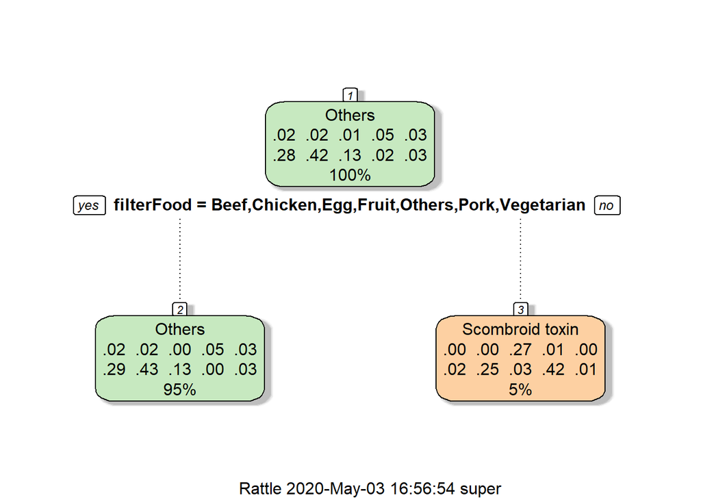

```r
fancyRpartPlot(dt_rout)
```

```r
#prune the tree
dt_rout_prune <- prune(dt_rout, cp = dt_rout$cptable[2,"CP"])


# plot the pruned tree
#fancyRpartPlot(dt_rout_prune)
```

## Random Forest

```r
loadPkg('randomForest')

set.seed(100)

# Training conducted using 3:1 training to testing ratio (without replacement)
train <- sample(nrow(model_data), 0.75*nrow(model_data), replace = FALSE)

train_set <- model_data[train,]
valid_set <- model_data[-train,]

summary(valid_set)
# summary(train_set)

rf <- randomForest(filterSpecies ~., data = train_set, mtry = 1, importance = TRUE)

rf

pred = predict(rf, newdata=valid_set[, !(colnames(valid_set) == "filterSpecies")])

# cm = table(valid_set[, "filterSpecies"], pred)

# cm
```

## Limitations of the Data

There were a variety of factors associated with the low accuracy of the models. First and foremost, there were simply too many levels to each variable. Attempting to group the Food, States, and Species was a difficult task. Each pathogen is unique and grouping them into only a few categories greatly increased error. The same occurred with the states. The states were grouped by climate, which is associated with the types of food outbreaks that occur. However, climate AND location (west coast versus east coast, etc.) are important when indicating whether it is likely to be one causative agent or another. Grouping the food by category was very difficult. There were thousands of variations of foods, as they were specific to the individual. Though the food is very important in determining causative agent (i.e. Salmonella grows on chicken), the environment of the food is also important. For instance, though there isn’t anything specific in potato salad that would clue you in to food poisoning, the fact that potato salad is often eaten at picnics where people leave food out for hours is a major variable. Additionally, Staphylococcus aureus and Shigella are both organisms that come from preparing food with dirty hands. So, food that is often prepared by hand, and not just the fact that it may be fish or chicken, is important. Because of these reasons, the food grouping made it very difficult to group the data. Increasing the number of groups to the maximum number of levels allows (32) or to use a different method of grouping may have increased the accuracy.

## Conclusion

To recap, our SMART question was the following:

How can we predict the causative agent (species) in foodborne disease outbreaks?

## References

Climate Data For Cities Worldwide. Climate-Data.org. https://en.climate-data.org/

James, G., Witten, D., Hastie, T., & Tibshirani, R. (2013). An introduction to statistical learning: with applications in R. New York, NY: Springer Science.

Koppen Climate Map of the United States. Plant Maps. https://www.plantmaps.com/koppen-climate-classification-map-united-states.php

“Foodborne Illness Outbreak Database - Sponsored by MarlerClark.” Outbreak Details, www.outbreakdatabase.com/details/taco-bell-restaurants-lettuce-2006/.

INFOSAN. “Escherichia Coli O157:H7 Outbreak in Spinach.” Food Safety Implications, 12 Feb. 2007, www.who.int/foodsafety/fs_management/No_01_spinach_Feb06_en.pdf.